# Árboles de decisión CART

###Ejemplo 1 - Base de datos “Titanic”

```r
# Instalar los paquetes necesarios para crear el árbol CART:
#install.packages("rpart")
#install.packages("rpart.plot")

# Librerías:
library(rpart)
library(rpart.plot)
library(readr)
library(tidyr)
library(dplyr)

#Leemos los datos del conjunto de entrenamiento:
datapath<-"C:/Users/danie/Dropbox/DOCENCIA/Maestria UNC/Datasets"
titanic.train<-read_delim(file=paste(datapath,'titanic.train.csv', sep="/"), delim = ",")
head(titanic.train)
```

```
## # A tibble: 6 x 12
##   PassengerId Survived Pclass Name    Sex     Age SibSp Parch Ticket  Fare Cabin
##         <dbl>    <dbl>  <dbl> <chr>   <chr> <dbl> <dbl> <dbl> <chr>  <dbl> <chr>
## 1           1        0      3 Braund~ male     22     1     0 A/5 2~  7.25 NA
## 2           2        1      1 Cuming~ fema~    38     1     0 PC 17~ 71.3  C85
## 3           3        1      3 Heikki~ fema~    26     0     0 STON/~  7.92 NA
## 4           4        1      1 Futrel~ fema~    35     1     0 113803 53.1  C123
## 5           5        0      3 Allen,~ male     35     0     0 373450  8.05 NA
## 6           6        0      3 Moran,~ male     NA     0     0 330877  8.46 NA
## # ... with 1 more variable: Embarked <chr>
```

##### Preparamos el conjunto de datos antes de construir el modelo:

```r
# Convertimos las variables de caracter a factores o factores ordenados según corresponda:
titanic.train<-mutate(titanic.train,
                      Survived=factor(Survived),
                      Pclass=factor(Pclass, ordered = T),
                      Embarked=factor(Embarked),
                      Sex=factor(Sex))

summary(titanic.train)
```

```
##   PassengerId    Survived Pclass      Name               Sex
##  Min.   :  1.0   0:549    1:216   Length:891         female:314
##  1st Qu.:223.5   1:342    2:184   Class :character   male  :577
##  Median :446.0            3:491   Mode  :character
##  Mean   :446.0
##  3rd Qu.:668.5
##  Max.   :891.0
##
##       Age            SibSp           Parch           Ticket
##  Min.   : 0.42   Min.   :0.000   Min.   :0.0000   Length:891
##  1st Qu.:20.12   1st Qu.:0.000   1st Qu.:0.0000   Class :character
##  Median :28.00   Median :0.000   Median :0.0000   Mode  :character
##  Mean   :29.70   Mean   :0.523   Mean   :0.3816
##  3rd Qu.:38.00   3rd Qu.:1.000   3rd Qu.:0.0000
##  Max.   :80.00   Max.   :8.000   Max.   :6.0000
##  NA's   :177
##       Fare           Cabin           Embarked
##  Min.   :  0.00   Length:891         C   :168
##  1st Qu.:  7.91   Class :character   Q   : 77
##  Median : 14.45   Mode  :character   S   :644
##  Mean   : 32.20                      NA's:  2
##  3rd Qu.: 31.00
##  Max.   :512.33
##
```

##### Con la base lista podemos comenzar a construir el árbol. El primer paso es seleccionar las variables que utilizaremos como predictores.

##### Las variables Name, Ticket y Cabin no se consideran puesto que sólo son variables de identificación de los pasajeros (al menos así como están no parece que pudieran aportar información relevante).

```r
# Guardamos la formula en un objeto para no tener que repetirla cada vez:

formula <- formula(Survived ~ Pclass + Sex + Age + SibSp + Parch + Fare + Embarked)

# Construimos el árbol (sin especificar ninguna opción personalizada):

arbol.titanic <- rpart(formula, data=titanic.train, method="class", set.seed(48))

# Imprimimos el objeto árbol:
arbol.titanic
```

```
## n= 891
##
## node), split, n, loss, yval, (yprob)
##       * denotes terminal node
##
##   1) root 891 342 0 (0.61616162 0.38383838)
##     2) Sex=male 577 109 0 (0.81109185 0.18890815)
##       4) Age>=6.5 553  93 0 (0.83182640 0.16817360) *
##       5) Age< 6.5 24   8 1 (0.33333333 0.66666667)
##        10) SibSp>=2.5 9   1 0 (0.88888889 0.11111111) *
##        11) SibSp< 2.5 15   0 1 (0.00000000 1.00000000) *
##     3) Sex=female 314  81 1 (0.25796178 0.74203822)
##       6) Pclass=3 144  72 0 (0.50000000 0.50000000)
##        12) Fare>=23.35 27   3 0 (0.88888889 0.11111111) *
##        13) Fare< 23.35 117  48 1 (0.41025641 0.58974359)
##          26) Embarked=S 63  31 0 (0.50793651 0.49206349)
##            52) Fare< 10.825 37  15 0 (0.59459459 0.40540541) *
##            53) Fare>=10.825 26  10 1 (0.38461538 0.61538462)
##             106) Fare>=17.6 10   3 0 (0.70000000 0.30000000) *
##             107) Fare< 17.6 16   3 1 (0.18750000 0.81250000) *
##          27) Embarked=C,Q 54  16 1 (0.29629630 0.70370370) *
##       7) Pclass=1,2 170   9 1 (0.05294118 0.94705882) *
```

##### Como vemos, esta impresión muestra la “descripción” del árbol creado en términos de las reglas que lo componen.

##### Podemos agregar a dicha descripción, la representación gráfica:

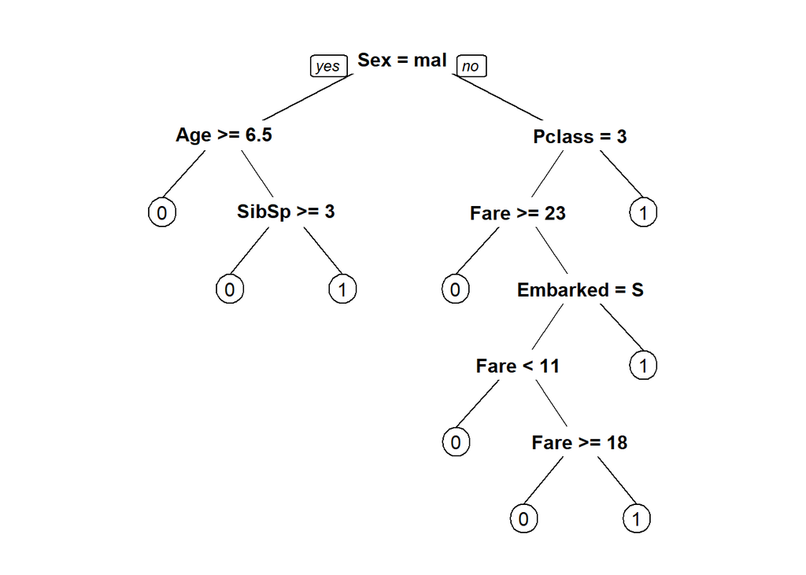

```r
prp(arbol.titanic) # Gráfico básico, sólo muestra las particiones y la predicción final.
```

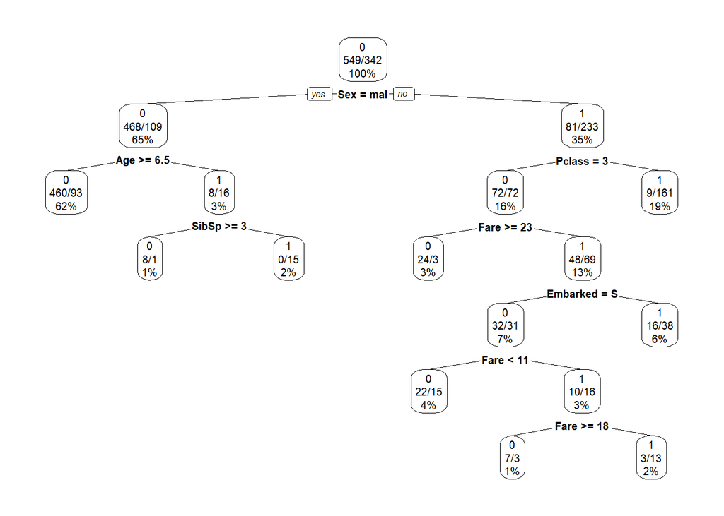

```r
prp(arbol.titanic, extra=101, type=2,  xsep="/") # con agregado de opciones para mejorar el formato de representación.
```

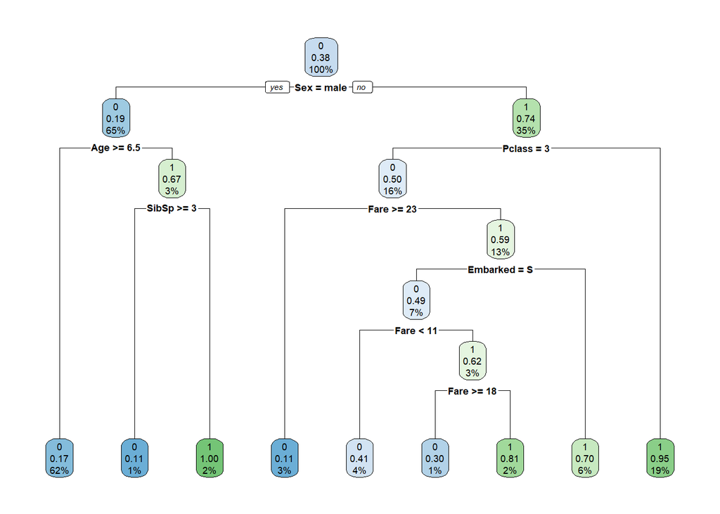

```r
rpart.plot(arbol.titanic) # otra función para graficar. Usa de base la función prp, pero ya tiene incorporadas ciertas especificaciones de presentación.
```

##### Dado que hemos utilizado la configuración por defecto para la creación del árbol, el mismo creció hasta lo que dichas especificaciones le permitieron.

##### Podríamos hacerlo crecer un poco más, especificando, por ejemplo, cp=0.

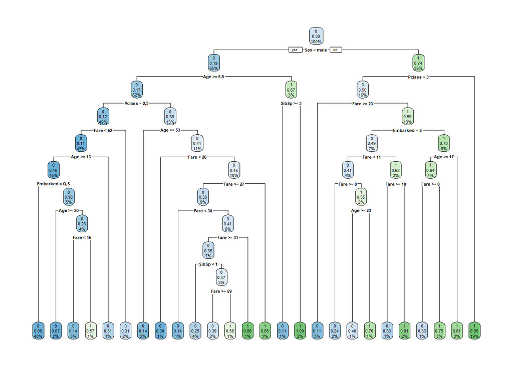

```r
arbol.titanic <- rpart(formula, data=titanic.train, method="class", set.seed(48), control=rpart.control(cp = 0))

rpart.plot(arbol.titanic)
```

##### Para analizar la relación de costo-complejidad del árbol podemos pedir la tabla de complejidades con la función “printcp” y graficar la curva del error de generalización con “plotcp”:

```r
printcp(arbol.titanic)
```

```
##
## Classification tree:
## rpart(formula = formula, data = titanic.train, weights = set.seed(48),
##     method = "class", control = rpart.control(cp = 0))
##
## Variables actually used in tree construction:
## [1] Age      Embarked Fare     Pclass   Sex      SibSp
##
## Root node error: 342/891 = 0.38384
##
## n= 891
##
##           CP nsplit rel error  xerror     xstd
## 1  0.4444444      0   1.00000 1.00000 0.042446
## 2  0.0307018      1   0.55556 0.55556 0.035750
## 3  0.0233918      3   0.49415 0.50000 0.034372
## 4  0.0204678      4   0.47076 0.49708 0.034295
## 5  0.0102339      5   0.45029 0.48830 0.034061
## 6  0.0065789      8   0.41813 0.49415 0.034217
## 7  0.0058480     14   0.37719 0.48538 0.033983
## 8  0.0043860     16   0.36550 0.47953 0.033824
## 9  0.0029240     18   0.35673 0.48246 0.033904
## 10 0.0005848     20   0.35088 0.49123 0.034140
## 11 0.0000000     25   0.34795 0.49415 0.034217
```

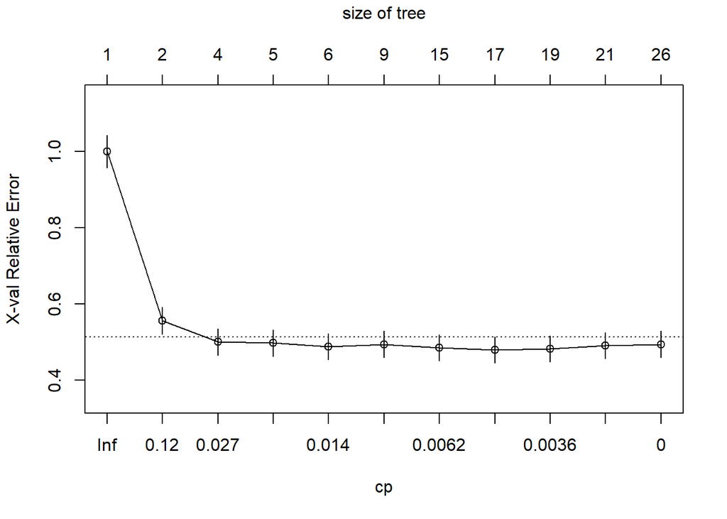

```r
plotcp(arbol.titanic)
```

##### Para podar el árbol en función de la complejidad elegida:

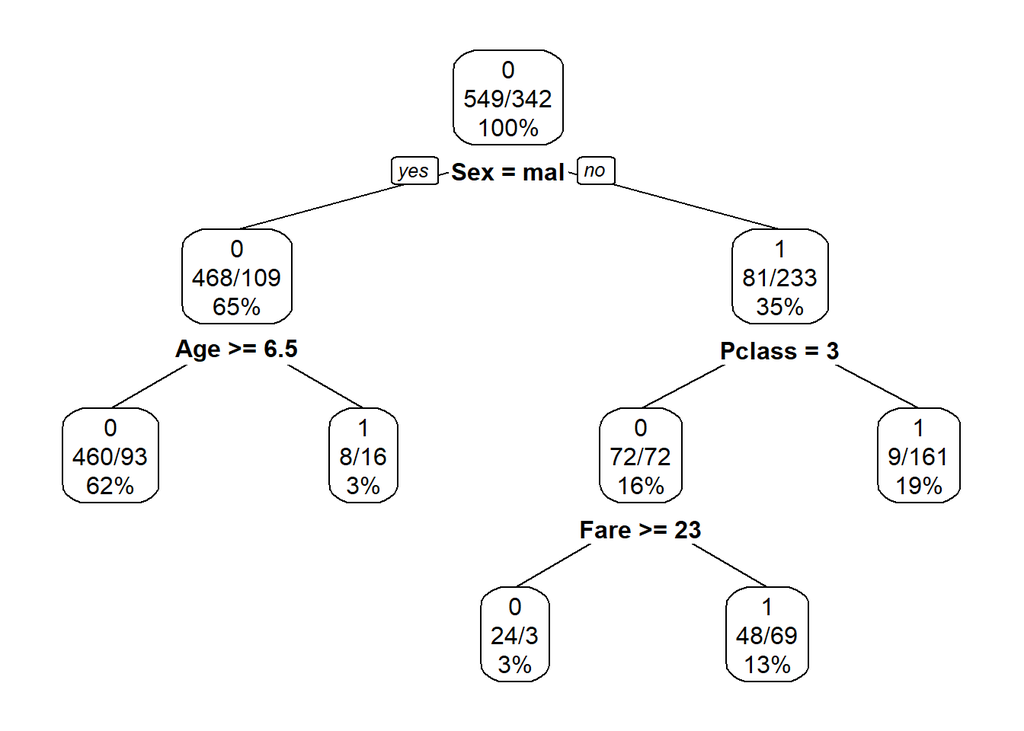

```r
arbol.titanic.podado<-prune(arbol.titanic, cp = 0.021) #retenemos sólo 4 particiones (valor de cp entre 0.0204678 y 0.0233918)
prp(arbol.titanic.podado, extra=101, type=2,  xsep="/")
```

##### Sobre este último árbol, la lectura del nodo raíz, por ejemplo, indica que se tienen 549+342=891 observaciones, que representan el 100% de los datos (en training) y que la respuesta estimada es 0, es decir, no sobrevive, (pues la P(SI)=342/891=0.38).

##### De la misma manera, la lectura del primer nodo terminal (de izquierda a derecha) indica que hay 460+93=553 personas de sexo masculino, de más de 6.5 años de edad, las cuales representan el 62% del total de personas en la base, y para ellos la respuesta estimada también es 0 (P(SI)=0.17).

##### La lectura de todos los nodos terminales, permite identificar el perfil de pasajero que sobrevive al naufragio.